# MSDS7331_Team3_MiniLab

## MSDS 7331: Data Mining

## Mini Lab: Logistic Regression and SVMs

## 16 June 2019

## Authors: Meredith Ludlow, Anand Rajan, Kristen Rollins, and Tej Tenmattam

# Create Models

**Rubric 1:** Create a logistic regression model and a support vector machine model for the classification task involved with your dataset. Assess how well each model performs (use 80/20 training/testing split for your data). Adjust parameters of the models to make them more accurate. If your dataset size requires the use of stochastic gradient descent, then linear kernel only is fine to use. That is, the SGDClassifier is fine to use for optimizing logistic regression and linear support vector machines. For many problems, SGD will be required in order to train the SVM model in a reasonable timeframe.

The classification task for our 2017 census dataset is to predict whether a given census tract has a high or a low unemployment rate. This is an important task, as it enables certain areas to be flagged as needing economic development or aid. Below, we first prepared our data for classification by cleaning it (in the same way as Lab 1), as well as removing unnecessary and redundant variables. We then split the data into training (80%) and testing (20%) sets. We created several logistic regression models with varying parameters, as well as some support vector machine models. We did an additional run of the models with an even further reduced dataset to compare performance.

#### Preparing Data

```python
# importing necessary packages
import pandas as pd
import numpy as np
import matplotlib.pyplot as plt
%matplotlib inline
import seaborn as sns

# Set seaborn plot styles
sns.set_style('darkgrid')
sns.set_color_codes('muted')

import warnings
warnings.filterwarnings("ignore") # ignore warnings for clean report

# df.head() displays all the columns without truncating
pd.set_option('display.max_columns', None)

# read csv file as pandas dataframe
df_17_census = pd.read_csv('Data/acs2017_census_tract_data.csv')
```

```python
# Clean dataset as in lab 1
df_17_census.set_index('TractId', inplace=True) # set tract id as index

# Drop tracts where population is 0
df_17_cln = df_17_census.drop(df_17_census[df_17_census.TotalPop == 0].index)

# Drop tracts where child poverty or unemployment is null
df_17_cln = df_17_cln[np.isfinite(df_17_cln['ChildPoverty'])]
df_17_cln = df_17_cln[np.isfinite(df_17_cln['Unemployment'])]

# Impute to the median by each state
df_grouped = df_17_cln.groupby('State').transform(lambda x: x.fillna(x.median()))
df_17_cln['Income'] = df_grouped['Income']
df_17_cln['IncomeErr'] = df_grouped['IncomeErr']

# Impute remaining values to the overall median
df_17_cln = df_17_cln.fillna(df_17_cln.median())
```

```python
# Categorize the unemployed percentages into binary categories
# Make cutoff using median of clean dataset, so groups are roughly equal
df_17_cln['HighUnemployment'] = pd.cut(df_17_cln.Unemployment,[-1,6,101],labels=[0,1])
df_17_cln.HighUnemployment = df_17_cln.HighUnemployment.astype(np.int)
# 0 indicates low unemployment rate, 1 indicates high unemployment rate

df_17_cln.info() # matches cleaned dataset from lab 1
```

```
<class 'pandas.core.frame.DataFrame'>
Int64Index: 72889 entries, 1001020100 to 72153750602
Data columns (total 37 columns):
State               72889 non-null object
County              72889 non-null object
TotalPop            72889 non-null int64
Men                 72889 non-null int64
Women               72889 non-null int64
Hispanic            72889 non-null float64
White               72889 non-null float64
Black               72889 non-null float64
Native              72889 non-null float64
Asian               72889 non-null float64
Pacific             72889 non-null float64
VotingAgeCitizen    72889 non-null int64
Income              72889 non-null float64
IncomeErr           72889 non-null float64
IncomePerCap        72889 non-null float64
IncomePerCapErr     72889 non-null float64
Poverty             72889 non-null float64
ChildPoverty        72889 non-null float64
Professional        72889 non-null float64
Service             72889 non-null float64
Office              72889 non-null float64
Construction        72889 non-null float64
Production          72889 non-null float64
Drive               72889 non-null float64
Carpool             72889 non-null float64
Transit             72889 non-null float64
Walk                72889 non-null float64
OtherTransp         72889 non-null float64
WorkAtHome          72889 non-null float64
MeanCommute         72889 non-null float64
Employed            72889 non-null int64
PrivateWork         72889 non-null float64
PublicWork          72889 non-null float64
SelfEmployed        72889 non-null float64
FamilyWork          72889 non-null float64
Unemployment        72889 non-null float64
HighUnemployment    72889 non-null int32
dtypes: float64(29), int32(1), int64(5), object(2)
memory usage: 20.9+ MB
```

At this point we have a clean dataset with no missing values, that matches the info from the cleaned dataset we used in Lab 1. Our target variable is "HighUnemployment", with 1 signifying a tract with a high unemployment rate and a 0 indicating low unemployment. We created the cutoff between high and low unemployment to be 6 percent, which was the median value for the unemployment attribute. By using the median to separate the groups, the classes will be of roughly the same size.

Since this dataset has 35 attributes, next we eliminate some unnecessary and redundant variables to cut down on the high dimensionality of the dataset. We still consider this to be our "full" model, however, since we retained 27 attributes.

```python
# Create dataframe to use in logistic and SVM models
df_17_model = df_17_cln.copy()

# Eliminate non-useful and redundant variables
del df_17_model['State'] # encoding would result in too many added variables
del df_17_model['County'] # encoding would result in too many added variables
del df_17_model['Men'] # redundant to keep men and women
del df_17_model['Unemployment'] # already encoded to binary

# Eliminate more variables based on correlation plot (could maybe remove more)
del df_17_model['IncomeErr'] # only need to keep one income-related variable
del df_17_model['IncomePerCap'] # only need to keep one income-related variable
del df_17_model['IncomePerCapErr'] # only need to keep one income-related variable
del df_17_model['Transit'] # drive and transit were essentially inverses
del df_17_model['PublicWork'] # private and public work were essentially inverses

# All remaining variables are ints or floats so we do not have to do one-hot encoding

# Convert columns to percentages for consistency
df_17_model['Women'] = round(df_17_model['Women']/df_17_model['TotalPop']*100,1)
df_17_model['VotingAgeCitizen'] = round(df_17_model['VotingAgeCitizen']/df_17_model['TotalPop']*100,1)
df_17_model['Employed'] = round(df_17_model['Employed']/df_17_model['TotalPop']*100,1)

print(df_17_model.info())
df_17_model.head()
```

```
<class 'pandas.core.frame.DataFrame'>
Int64Index: 72889 entries, 1001020100 to 72153750602
Data columns (total 28 columns):
TotalPop            72889 non-null int64
Women               72889 non-null float64
Hispanic            72889 non-null float64
White               72889 non-null float64
Black               72889 non-null float64
Native              72889 non-null float64
Asian               72889 non-null float64
Pacific             72889 non-null float64
VotingAgeCitizen    72889 non-null float64
Income              72889 non-null float64
Poverty             72889 non-null float64
ChildPoverty        72889 non-null float64
Professional        72889 non-null float64
Service             72889 non-null float64
Office              72889 non-null float64
Construction        72889 non-null float64
Production          72889 non-null float64
Drive               72889 non-null float64
Carpool             72889 non-null float64
Walk                72889 non-null float64
OtherTransp         72889 non-null float64
WorkAtHome          72889 non-null float64
MeanCommute         72889 non-null float64
Employed            72889 non-null float64
PrivateWork         72889 non-null float64
SelfEmployed        72889 non-null float64
FamilyWork          72889 non-null float64
HighUnemployment    72889 non-null int32
dtypes: float64(26), int32(1), int64(1)
memory usage: 15.8 MB
None
```

| TractId | TotalPop | Women | Hispanic | White | Black | Native | Asian | Pacific | VotingAgeCitizen | Income | Poverty | ChildPoverty | Professional | Service | Office | Construction | Production | Drive | Carpool | Walk | OtherTransp | WorkAtHome | MeanCommute | Employed | PrivateWork | SelfEmployed | FamilyWork | HighUnemployment |
| --- | --- | --- | --- | --- | --- | --- | --- | --- | --- | --- | --- | --- | --- | --- | --- | --- | --- | --- | --- | --- | --- | --- | --- | --- | --- | --- | --- | --- |
| 1001020100 | 1845 | 51.3 | 2.4 | 86.3 | 5.2 | 0.0 | 1.2 | 0.0 | 76.3 | 67826.0 | 10.7 | 20.8 | 38.5 | 15.6 | 22.8 | 10.8 | 12.4 | 94.2 | 3.3 | 0.5 | 0.0 | 2.1 | 24.5 | 47.8 | 74.2 | 4.5 | 0.0 | 0 |
| 1001020200 | 2172 | 46.3 | 1.1 | 41.6 | 54.5 | 0.0 | 1.0 | 0.0 | 76.1 | 41287.0 | 22.4 | 35.8 | 30.5 | 24.9 | 22.9 | 6.3 | 15.4 | 90.5 | 9.1 | 0.0 | 0.5 | 0.0 | 22.2 | 39.2 | 75.9 | 9.0 | 0.0 | 0 |
| 1001020300 | 3385 | 54.7 | 8.0 | 61.4 | 26.5 | 0.6 | 0.7 | 0.4 | 73.3 | 46806.0 | 14.7 | 21.1 | 27.9 | 19.4 | 33.3 | 9.9 | 9.6 | 88.3 | 8.4 | 1.0 | 0.8 | 1.5 | 23.1 | 43.8 | 73.3 | 4.8 | 0.7 | 0 |
| 1001020400 | 4267 | 53.1 | 9.6 | 80.3 | 7.1 | 0.5 | 0.2 | 0.0 | 76.3 | 55895.0 | 2.3 | 1.7 | 29.0 | 16.6 | 25.8 | 9.1 | 19.5 | 82.3 | 11.2 | 1.5 | 2.9 | 2.1 | 25.9 | 43.3 | 75.8 | 4.5 | 0.0 | 1 |
| 1001020500 | 9965 | 49.3 | 0.9 | 77.5 | 16.4 | 0.0 | 3.1 | 0.0 | 72.5 | 68143.0 | 12.2 | 17.9 | 48.8 | 13.8 | 20.5 | 3.5 | 13.4 | 86.9 | 11.2 | 0.8 | 0.3 | 0.7 | 21.0 | 48.0 | 71.4 | 4.5 | 0.0 | 0 |

#### Train/Test Split

```python
# Following code from Dr. Larson's Logits and SVM notebook
from sklearn.model_selection import ShuffleSplit

# we want to predict the X and y data as follows:
if 'HighUnemployment' in df_17_model:
    y = df_17_model['HighUnemployment'].values # get the labels we want
    del df_17_model['HighUnemployment'] # get rid of the class label
    X = df_17_model.values # use everything else to predict


# 10 fold cross-validation
num_cv_iterations = 10
num_instances = len(y)
cv_object = ShuffleSplit(n_splits=num_cv_iterations,
                         test_size  = 0.2)

print(cv_object)
```

```
ShuffleSplit(n_splits=10, random_state=None, test_size=0.2, train_size=None)
```

## Logistic Regression

In the code that follows, we have created several logistic regression models to arrive at the best performing one, by adjusting the model parameters.

##### Find the best tuned hyperplane parameters for Logistic Regression

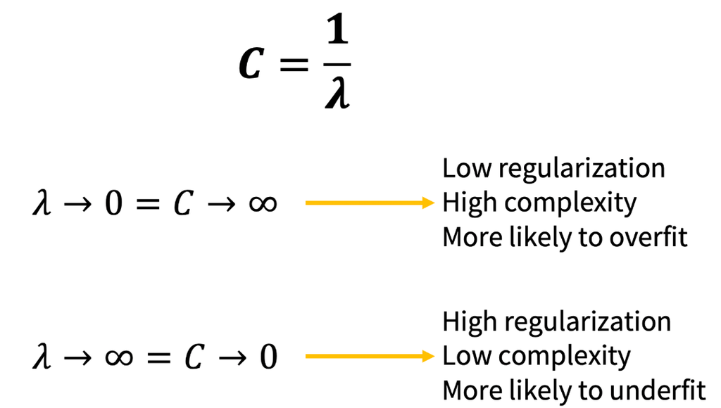

```python
# run logistic regression and vary some parameters
from sklearn.linear_model import LogisticRegression
from sklearn import metrics as mt
# also scale variables
from sklearn.preprocessing import StandardScaler
scl_obj = StandardScaler()
```

```python
# Function to print the results
def print_results(results):
    print('BEST PARAMS: {}\n'.format(results.best_params_))

    means = results.cv_results_['mean_test_score']
    stds = results.cv_results_['std_test_score']
    for mean, std, params in zip(means, stds, results.cv_results_['params']):
        print('{} (+/-{}) for {}'.format(round(mean, 3), round(std * 2, 3), params))
```

```python
# Find the best hyperplane parameters for Logistic Regression
import joblib
import pandas as pd
from sklearn.linear_model import LogisticRegression
from sklearn.model_selection import GridSearchCV
import warnings
warnings.filterwarnings('ignore', category=FutureWarning)
warnings.filterwarnings('ignore', category=DeprecationWarning)

lr = LogisticRegression()
parameters = {
    'C': [0.001, 0.01, 0.1, 1, 10, 100, 1000]
}

lr_cv = GridSearchCV(lr, parameters, cv=5)
lr_cv.fit(X, y)

print_results(lr_cv)
```

```
BEST PARAMS: {'C': 100}

0.738 (+/-0.02) for {'C': 0.001}
0.738 (+/-0.021) for {'C': 0.01}
0.738 (+/-0.02) for {'C': 0.1}
0.738 (+/-0.021) for {'C': 1}
0.738 (+/-0.021) for {'C': 10}
0.738 (+/-0.019) for {'C': 100}
0.738 (+/-0.021) for {'C': 1000}
```

```python
# Display the best estimator with the recommended hyperplane parameters
lr_cv.best_estimator_
```

```
LogisticRegression(C=100, class_weight=None, dual=False, fit_intercept=True,
          intercept_scaling=1, max_iter=100, multi_class='warn',
          n_jobs=None, penalty='l2', random_state=None, solver='warn',
          tol=0.0001, verbose=0, warm_start=False)
```

```python
# Output this to a model.pkl file
#joblib.dump(lr_cv.best_estimator_, 'LR_full_model.pkl')
```

```python
lr_clf = LogisticRegression(C=100, class_weight=None, dual=False, fit_intercept=True,
          intercept_scaling=1, max_iter=100, multi_class='warn',
          n_jobs=None, penalty='l2', random_state=None, solver='warn',
          tol=0.0001, verbose=0, warm_start=False)
        #class_weight=None because unemployment groups are weighted equally

for iter_num, (train_indices, test_indices) in enumerate(cv_object.split(X,y)):
    # scale attributes by the training set
    scl_obj.fit(X[train_indices])
    X_train_scaled = scl_obj.transform(X[train_indices]) # apply to training
    X_test_scaled = scl_obj.transform(X[test_indices]) # use training scales to adjust test set, so we're not cheating

    # train object
    lr_clf.fit(X_train_scaled,y[train_indices])
    # get test set precitions
    y_hat = lr_clf.predict(X_test_scaled)

    # print the accuracy and confusion matrix
    print("====Iteration",iter_num," ====")
    print("Precision:",mt.precision_score(y[test_indices],y_hat))
    print("Recall:",mt.recall_score(y[test_indices],y_hat))
    print("accuracy", mt.accuracy_score(y[test_indices],y_hat))
    print("confusion matrix\n",mt.confusion_matrix(y[test_indices],y_hat))
```

```
====Iteration 0  ====
Precision: 0.7592089371980676
Recall: 0.703061652453516
accuracy 0.7448895596103718
confusion matrix
 [[5830 1595]
 [2124 5029]]
====Iteration 1  ====
Precision: 0.7587292072531095
Recall: 0.7052514277754562
accuracy 0.7444093840032926
confusion matrix
 [[5789 1610]
 [2116 5063]]
====Iteration 2  ====
Precision: 0.755935702698717
Recall: 0.7104643104643105
accuracy 0.7431746467279462
confusion matrix
 [[5708 1655]
 [2089 5126]]
====Iteration 3  ====
Precision: 0.7656014470907446
Recall: 0.7058087826570317
accuracy 0.7481135958293319
confusion matrix
 [[5827 1555]
 [2117 5079]]
====Iteration 4  ====
Precision: 0.7563314850891653
Recall: 0.7060716284275321
accuracy 0.7443407874879956
confusion matrix
 [[5804 1626]
 [2101 5047]]
====Iteration 5  ====
Precision: 0.7618834080717489
Recall: 0.7153684210526315
accuracy 0.7516120181094801
confusion matrix
```

[output cut: 15 more lines]

```
 [2122 5042]]
====Iteration 8  ====
Precision: 0.768586387434555
Recall: 0.7078109932497589
accuracy 0.7483879818905199
confusion matrix
 [[5772 1547]
 [2121 5138]]
====Iteration 9  ====
Precision: 0.7644728823887873
Recall: 0.7035894559730791
accuracy 0.7489367540128962
confusion matrix
 [[5900 1546]
 [2114 5018]]
```

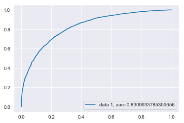

```python
#ROC Curve for LR model above
y_pred_prob = lr_clf.predict_proba(X_test_scaled)[::,1]
fpr, tpr, _ = mt.roc_curve(y[test_indices],  y_pred_prob)
auc = mt.roc_auc_score(y[test_indices], y_pred_prob)
plt.plot(fpr,tpr,label="data 1, auc="+str(auc))
plt.legend(loc=4)
plt.show()
```

```python
# Influential features printing out all the coefficients
print (lr_clf.coef_)
print(np.std(X, 0)*lr_clf.coef_)
```

```
[[-0.04346276  0.07330617 -0.84285741 -1.60381699 -0.67069445 -0.13766897
  -0.37452402 -0.09251545  0.28300543 -0.17396651  0.58511171 -0.05822574
  -0.09910238  0.18781508  0.03182687 -0.04502855  0.06177313  0.0155178
   0.04229644 -0.03873774  0.03085389 -0.05439382  0.28178182 -0.65236659
   0.04713016 -0.02787802 -0.03367121]]
[[-9.52928727e+01  3.06308489e-01 -1.94677574e+01 -4.91337198e+01
  -1.44862045e+01 -6.22967556e-01 -3.36797495e+00 -9.46494786e-02
   2.95588095e+00 -5.30456531e+03  7.32238608e+00 -1.08552771e+00
  -1.49583248e+00  1.50961996e+00  1.79933044e-01 -2.69262298e-01
   4.71286472e-01  2.33729428e-01  2.18576406e-01 -2.09127343e-01
   7.77000983e-02 -2.07888710e-01  2.00093828e+00 -5.91134287e+00
   3.77859421e-01 -1.07220032e-01 -1.53351180e-02]]
```

### Stochastic Gradient Descent

We also performed Stochastic Gradient Descent (SGD) with Logistic Regression as a tool to improve performance and potentially improve accuracy. We first performed this technique on the full dataset, then on a reduced dataset using the most important features.

Stochastic Gradient Descent is done minimizing a function tracing a path of the cost function until it reaches a minimum value. In this machine learning the model is gradually updated to reduce the prediction error that follows. It requires two parameters: a. Learning rate - which limits the updates to correct the coefficient each iteration. b. Epochs - number of times to run through the training set to update coefficients.

The logic flows as below: First loop through the epoch Within this loop go through each training data for epoch for each update the coefficient for the epoch (repetitions) including the intercept.

We use numpy to the sigmoid function to arrive at the losses.

```python
# defines the sigmoid function
def sigmoid(x):
# calculates and  returns the sigmoid activation value for input x
    return 1.0 / (1 + np.exp(-x))
```

```python
#defining the cost function here - uses sigmoid function to compute logistic regression cost
def cost_f(x, y, theta):
    t = x.dot(theta)
    return -np.sum(y*np.log(sigmoid(t))+(1-y)* np.log(1-sigmoid(t)))/x.shape[0]
# defined gradient cost which can also be alternately used.
def grad_cost(x,y,theta):
    t=x.dot(theta)
    return x.T.dot(y - sigmoid(t)) / x.shape[0]
```

#### Main part of SGD

```python
#defining the update function for training.
def update_theta(x, y, theta, lr):
    return theta + lr * grad_cost(x, y, theta)

def train(x, y, lr, iterations=100, threshold=0.0005):
    theta = np.zeros(x.shape[1])
    costs = []
    print('Started to train')
    for i in range(iterations):
        theta = update_theta(x, y, theta, lr)
        cost = cost_f(x, y, theta)
        print(f'[Training step number: {i}] — Cost function: {cost:.4f}')
        costs.append({'cost': cost, 'wts': theta})
        if i > 15 and abs(costs[-2]['cost']-costs[-1]['cost']) < threshold:
            break
        return theta, costs
```

```python
#Now using the earlier model used for logistic regression using CV to do the training.
theta, cost = train(X_train_scaled, y[train_indices], lr=0.05)

#Now we can predict based on our model
def predict(x, theta):
    return (sigmoid(x.dot(theta)) >=0.5).astype(int)

def get_accuracy(x,y,theta):
    ypred=predict(x,theta)
    return (ypred == y).sum()/y.shape[0]

print(f'Accuracy -training:{get_accuracy(X_train_scaled, y[train_indices], theta)}')
print(f'Accuracy -test:{get_accuracy(X_test_scaled, y[test_indices], theta)}')
```

```
Started to train
[Training step number: 0] — Cost function: 0.6757
Accuracy -training:0.730291025706985
Accuracy -test:0.7379613115653725
```

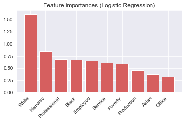

```python
from sklearn.linear_model import LogisticRegressionCV

#Features most important using Logistic regression
#https://stats.stackexchange.com/questions/336404/feature-importance-for-breast-cancer-random-forests-vs-logistic-regression
#https://towardsdatascience.com/model-based-feature-importance-d4f6fb2ad403
#The best hyperparameter offered a log loss of .675 and accuracy of 73% which is somewhat good.

clf = LogisticRegressionCV(max_iter=3000)
clf.fit(X_train_scaled, y[train_indices])
coefs = np.abs(clf.coef_[0])
indices = np.argsort(coefs)[::-1]

plt.figure()
plt.title("Feature importances (Logistic Regression)")
plt.bar(range(10), coefs[indices[:10]],
       color="r", align="center")
plt.xticks(range(10), df_17_model.columns[indices[:10]], rotation=45, ha='right')
plt.subplots_adjust(bottom=0.3)

plt.ion(); plt.show()
```

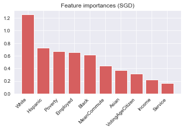

```python
from sklearn.linear_model import SGDClassifier

#Features most important using Logistic regression

#The best hyperparameter offered a log loss of .675 and accuracy of 73% which is somewhat good.


SGD = SGDClassifier(loss="log", penalty = "l2", max_iter=500, tol=1e-3)
SGD.fit(X_train_scaled,y[train_indices])

coefs = np.abs(SGD.coef_[0])
indices = np.argsort(coefs)[::-1]

plt.figure()
plt.title("Feature importances (SGD)")
plt.bar(range(10), coefs[indices[:10]],
       color="r", align="center")
plt.xticks(range(10), df_17_model.columns[indices[:10]], rotation=45, ha='right')
plt.subplots_adjust(bottom=0.3)

plt.ion(); plt.show()
```

#### Calculation of SGD - Theta and Cost using features determined

```python
#### This is a different set of data for which we plotted the theta and cost for comparison.
from sklearn.linear_model import SGDClassifier
from sklearn.preprocessing import StandardScaler
import warnings
warnings.filterwarnings('ignore', category=FutureWarning)
warnings.filterwarnings('ignore', category=DeprecationWarning)

df_17_model2 = df_17_model.copy()

X = df_17_model2[['White','Employed','Hispanic','Poverty','Black']].values

if 'HighUnemployment' in df_17_model:
    y = df_17_model2['HighUnemployment'].values # get the labels we want
    del df_17_model2['HighUnemployment'] # get rid of the class label

#Set some parameters for iteration 5 fold cv for new set
num_cv_iter = 5
num_inst = len(y)
cv_obj = ShuffleSplit(n_splits=num_cv_iter,
                         test_size  = 0.2)

print(cv_obj)
scl = StandardScaler()
for iter_n, (train_ind, test_ind) in enumerate(cv_obj.split(X,y)):
    # scale attributes by the training set
    scl.fit(X[train_ind])
    X_train_scl = scl.transform(X[train_ind]) # apply to training
    X_test_scl = scl.transform(X[test_ind]) # use training scales to adjust test set
```

```
ShuffleSplit(n_splits=5, random_state=None, test_size=0.2, train_size=None)
```

```python
#Now using the reduced model
theta, cost = train(X_train_scl, y[train_ind], lr=0.05)

#Now we can predict based on our model
def predict(x, theta):
    return (sigmoid(x.dot(theta)) >=0.5).astype(int)

def get_accuracy(x,y,theta):
    ypred=predict(x,theta)
    return (ypred == y).sum()/y.shape[0]

print(f'Accuracy -training:{get_accuracy(X_train_scl, y[train_ind], theta)}')
print(f'Accuracy -test:{get_accuracy(X_test_scl, y[test_ind], theta)}')
```

```
Started to train
[Training step number: 0] — Cost function: 0.6854
Accuracy -training:0.7233798082694517
Accuracy -test:0.721566744409384
```

## Support Vector Machine

In the following code, we have created a few Support Vector Machine models to classify high and low unemployment, to compare with Logistic Regression. We first attempted to fine-tune the model parameters as we did for LR, but this proved too computationally expensive. Therefore we created and compared two different SVM models and chose the better one.

##### Find the best tuned hyperplane parameters for SVM

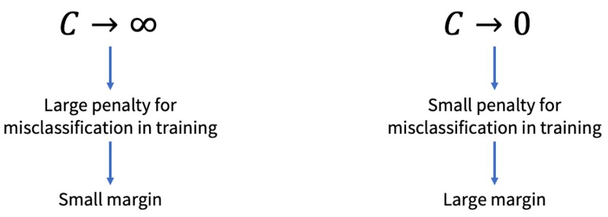

```python
### Support Vector Machines: Fit and evaluate a model
import joblib
import pandas as pd
from sklearn.model_selection import GridSearchCV
from sklearn.svm import SVC
import warnings
warnings.filterwarnings('ignore', category=FutureWarning)
warnings.filterwarnings('ignore', category=DeprecationWarning)
```

```python
def print_results(results):
    print('BEST PARAMS: {}\n'.format(results.best_params_))

    means = results.cv_results_['mean_test_score']
    stds = results.cv_results_['std_test_score']
    for mean, std, params in zip(means, stds, results.cv_results_['params']):
        print('{} (+/-{}) for {}'.format(round(mean, 3), round(std * 2, 3), params))
```

Note: The code below is computationally very intensive and takes a long time. First we tried to find the best C value between 0.1, 1 and 10 with a cv of 5 but it was taking too long so we decided to use a C of 0.5.

We are commenting out the code below, so that we can skip and run it only when needed. Output is shown as an image below.

```python
#svc = SVC()
#parameters = {
#    'kernel': ['linear', 'rbf'],
#    'C': [0.5]
#}

#svm_cv = GridSearchCV(svc, parameters, cv=5)
#svm_cv.fit(X,y)

#print_results(svm_cv)
```

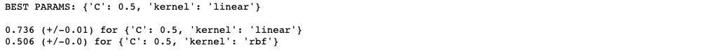

**Linear kernel parameter (73.6%) performed better than rbf (50.6%).**

```python
# Display the best estimator with the recommended hyperplane parameters
# svm_cv.best_estimator_
```

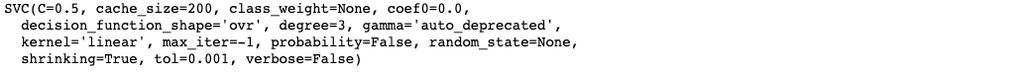

```python
# Output this to a model.pkl file
# joblib.dump(svm_cv.best_estimator_, 'SVM_full_model.pkl')
```

```python
svm_clf = SVC(C=0.5, cache_size=200, class_weight=None, coef0=0.0,
              decision_function_shape='ovr', degree=3, gamma='auto_deprecated',
              kernel='linear', max_iter=-1, probability=False, random_state=None,
              shrinking=True, tol=0.001, verbose=False)

for iter_num, (train_indices, test_indices) in enumerate(cv_object.split(X,y)):
    # scale attributes by the training set
    scl_obj.fit(X[train_indices])
    X_train_scaled = scl_obj.transform(X[train_indices]) # apply to training
    X_test_scaled = scl_obj.transform(X[test_indices]) # use training scales to adjust test set, so we're not cheating

    # train object
    svm_clf.fit(X_train_scaled,y[train_indices])
    # get test set precitions
    y_hat = svm_clf.predict(X_test_scaled)

    # print the accuracy and confusion matrix
    print("====Iteration",iter_num," ====")
    print("Precision:",mt.precision_score(y[test_indices],y_hat))
    print("Recall:",mt.recall_score(y[test_indices],y_hat))
    print("accuracy", mt.accuracy_score(y[test_indices],y_hat))
    print("confusion matrix\n",mt.confusion_matrix(y[test_indices],y_hat))
```

```
====Iteration 0  ====
Precision: 0.7206810509320417
Recall: 0.6891228070175439
accuracy 0.7175195500068596
confusion matrix
 [[5550 1903]
 [2215 4910]]
====Iteration 1  ====
Precision: 0.7247800586510263
Recall: 0.6924908938077893
accuracy 0.7206749897105227
confusion matrix
 [[5563 1877]
 [2195 4943]]
====Iteration 2  ====
Precision: 0.7230252591619214
Recall: 0.6868238557558946
accuracy 0.7149814789408698
confusion matrix
 [[5471 1897]
 [2258 4952]]
====Iteration 3  ====
Precision: 0.714223066803099
Recall: 0.691089108910891
accuracy 0.7160790231856222
confusion matrix
 [[5553 1955]
 [2184 4886]]
====Iteration 4  ====
Precision: 0.7251684734837387
Recall: 0.6888394099638185
accuracy 0.7179311290986418
confusion matrix
 [[5516 1876]
 [2236 4950]]
====Iteration 5  ====
Precision: 0.7243052492280547
Recall: 0.6850229453483521
accuracy 0.7160104266703251
confusion matrix
```

[output cut: 15 more lines]

```
 [2285 4875]]
====Iteration 8  ====
Precision: 0.7262660564004134
Recall: 0.6856704767214943
accuracy 0.7181369186445329
confusion matrix
 [[5550 1854]
 [2255 4919]]
====Iteration 9  ====
Precision: 0.7255963705546612
Recall: 0.6904330873137446
accuracy 0.7188914803128001
confusion matrix
 [[5522 1875]
 [2223 4958]]
```

## Reduced Model with features from PCA

The above analysis was performed on a dataset with 27 attributes, obtained from manual deletion of only a few variables. We recognize the dangers of overfitting with so many features being used, so we decided to reduce the dimensionality of our dataset greatly and run the Logistic and SVM models again. The features in this reduced dataset were selected based on PCA performed in Lab 1, so just 6 variables were chosen to explain the highest amount of variance in the dataset.

```python
# Categorize the unemployed percentages into binary categories
# Make cutoff using median of clean dataset, so groups are roughly equal
df_17_cln['HighUnemployment'] = pd.cut(df_17_cln.Unemployment,[-1,6,101],labels=[0,1])
df_17_cln.HighUnemployment = df_17_cln.HighUnemployment.astype(np.int)
# 0 indicates low unemployment rate, 1 indicates high unemployment rate

df_17_cln.info() # matches cleaned dataset from lab 1
```

```
<class 'pandas.core.frame.DataFrame'>
Int64Index: 72889 entries, 1001020100 to 72153750602
Data columns (total 37 columns):
State               72889 non-null object
County              72889 non-null object
TotalPop            72889 non-null int64
Men                 72889 non-null int64
Women               72889 non-null int64
Hispanic            72889 non-null float64
White               72889 non-null float64
Black               72889 non-null float64
Native              72889 non-null float64
Asian               72889 non-null float64
Pacific             72889 non-null float64
VotingAgeCitizen    72889 non-null int64
Income              72889 non-null float64
IncomeErr           72889 non-null float64
IncomePerCap        72889 non-null float64
IncomePerCapErr     72889 non-null float64
Poverty             72889 non-null float64
ChildPoverty        72889 non-null float64
Professional        72889 non-null float64
Service             72889 non-null float64
Office              72889 non-null float64
Construction        72889 non-null float64
Production          72889 non-null float64
Drive               72889 non-null float64
Carpool             72889 non-null float64
Transit             72889 non-null float64
Walk                72889 non-null float64
OtherTransp         72889 non-null float64
WorkAtHome          72889 non-null float64
MeanCommute         72889 non-null float64
Employed            72889 non-null int64
PrivateWork         72889 non-null float64
PublicWork          72889 non-null float64
SelfEmployed        72889 non-null float64
FamilyWork          72889 non-null float64
Unemployment        72889 non-null float64
HighUnemployment    72889 non-null int64
dtypes: float64(29), int64(6), object(2)
memory usage: 21.1+ MB
```

```python
# Create dataframe to use in logistic and SVM models
df_pca_model = df_17_cln.copy()
#New features for PCA analysis
df_pca_model['Income_thousands'] = df_pca_model['Income'] / 1000
```

```python
df_pca_model.head()
```

| TractId | State | County | TotalPop | Men | Women | Hispanic | White | Black | Native | Asian | Pacific | VotingAgeCitizen | Income | IncomeErr | IncomePerCap | IncomePerCapErr | Poverty | ChildPoverty | Professional | Service | Office | Construction | Production | Drive | Carpool | Transit | Walk | OtherTransp | WorkAtHome | … |
| --- | --- | --- | --- | --- | --- | --- | --- | --- | --- | --- | --- | --- | --- | --- | --- | --- | --- | --- | --- | --- | --- | --- | --- | --- | --- | --- | --- | --- | --- | --- |
| 1001020100 | Alabama | Autauga County | 1845 | 899 | 946 | 2.4 | 86.3 | 5.2 | 0.0 | 1.2 | 0.0 | 1407 | 67826.0 | 14560.0 | 33018.0 | 6294.0 | 10.7 | 20.8 | 38.5 | 15.6 | 22.8 | 10.8 | 12.4 | 94.2 | 3.3 | 0.0 | 0.5 | 0.0 | 2.1 | … |
| 1001020200 | Alabama | Autauga County | 2172 | 1167 | 1005 | 1.1 | 41.6 | 54.5 | 0.0 | 1.0 | 0.0 | 1652 | 41287.0 | 3819.0 | 18996.0 | 2453.0 | 22.4 | 35.8 | 30.5 | 24.9 | 22.9 | 6.3 | 15.4 | 90.5 | 9.1 | 0.0 | 0.0 | 0.5 | 0.0 | … |
| 1001020300 | Alabama | Autauga County | 3385 | 1533 | 1852 | 8.0 | 61.4 | 26.5 | 0.6 | 0.7 | 0.4 | 2480 | 46806.0 | 9496.0 | 21236.0 | 2562.0 | 14.7 | 21.1 | 27.9 | 19.4 | 33.3 | 9.9 | 9.6 | 88.3 | 8.4 | 0.0 | 1.0 | 0.8 | 1.5 | … |
| 1001020400 | Alabama | Autauga County | 4267 | 2001 | 2266 | 9.6 | 80.3 | 7.1 | 0.5 | 0.2 | 0.0 | 3257 | 55895.0 | 4369.0 | 28068.0 | 3190.0 | 2.3 | 1.7 | 29.0 | 16.6 | 25.8 | 9.1 | 19.5 | 82.3 | 11.2 | 0.0 | 1.5 | 2.9 | 2.1 | … |
| 1001020500 | Alabama | Autauga County | 9965 | 5054 | 4911 | 0.9 | 77.5 | 16.4 | 0.0 | 3.1 | 0.0 | 7229 | 68143.0 | 14424.0 | 36905.0 | 10706.0 | 12.2 | 17.9 | 48.8 | 13.8 | 20.5 | 3.5 | 13.4 | 86.9 | 11.2 | 0.0 | 0.8 | 0.3 | 0.7 | … |

From PCA analysis done in Lab 1 (image shown below), features "Income in thousands", "Drive", "Professional", "Private Work", "Mean Commute" and "Service" are the predictor variables that act as a major role in estabishing the principal components.

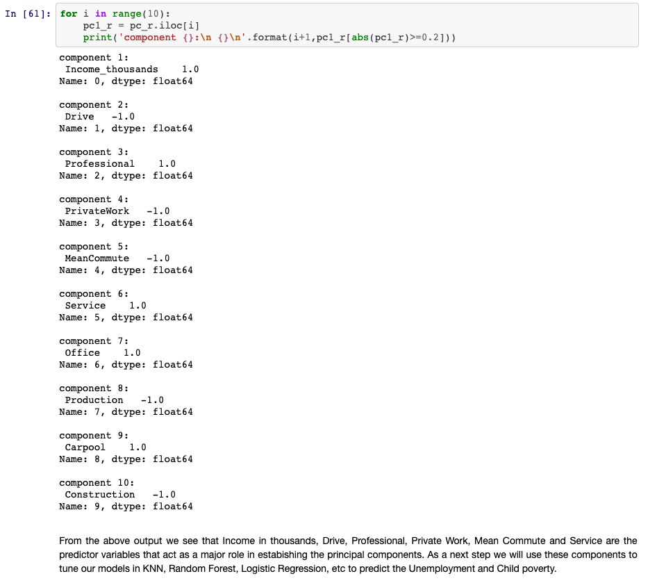

```python
# Trim our dataframe to the pca components
del df_pca_model['TotalPop']
del df_pca_model['Women']
del df_pca_model['Hispanic']
del df_pca_model['White']
del df_pca_model['Black']
del df_pca_model['Native']
del df_pca_model['Asian']
del df_pca_model['Pacific']
del df_pca_model['VotingAgeCitizen']
del df_pca_model['Income']
del df_pca_model['Poverty']
del df_pca_model['ChildPoverty']
del df_pca_model['Office']
del df_pca_model['Construction']
del df_pca_model['Production']
del df_pca_model['Carpool']
del df_pca_model['Walk']
del df_pca_model['OtherTransp']
del df_pca_model['WorkAtHome']
del df_pca_model['Employed']
del df_pca_model['SelfEmployed']
del df_pca_model['FamilyWork']
del df_pca_model['State']
del df_pca_model['County']
del df_pca_model['Men']
del df_pca_model['Unemployment']
del df_pca_model['IncomeErr']
del df_pca_model['IncomePerCap']
del df_pca_model['IncomePerCapErr']
del df_pca_model['Transit']
del df_pca_model['PublicWork']
```

```python
df_pca_model.head()
```

| TractId | Professional | Service | Drive | MeanCommute | PrivateWork | HighUnemployment | Income_thousands |
| --- | --- | --- | --- | --- | --- | --- | --- |
| 1001020100 | 38.5 | 15.6 | 94.2 | 24.5 | 74.2 | 0 | 67.826 |
| 1001020200 | 30.5 | 24.9 | 90.5 | 22.2 | 75.9 | 0 | 41.287 |
| 1001020300 | 27.9 | 19.4 | 88.3 | 23.1 | 73.3 | 0 | 46.806 |
| 1001020400 | 29.0 | 16.6 | 82.3 | 25.9 | 75.8 | 1 | 55.895 |
| 1001020500 | 48.8 | 13.8 | 86.9 | 21.0 | 71.4 | 0 | 68.143 |

```python
### Split into train and test set
import pandas as pd
from sklearn.model_selection import train_test_split

features = df_pca_model.drop('HighUnemployment', axis=1)
labels = df_pca_model['HighUnemployment']

X_train, X_test, y_train, y_test = train_test_split(features, labels, test_size=0.2, random_state=42)
```

```python
# Show that we got 80/20 split
for dataset in [y_train, y_test]:
    print(round(len(dataset) / len(labels), 2))
```

```
0.8
0.2
```

```python
# Function to print the results
def print_results(results):
    print('BEST PARAMS: {}\n'.format(results.best_params_))

    means = results.cv_results_['mean_test_score']
    stds = results.cv_results_['std_test_score']
    for mean, std, params in zip(means, stds, results.cv_results_['params']):
        print('{} (+/-{}) for {}'.format(round(mean, 3), round(std * 2, 3), params))
```

```python
# Find the best hyperplane parameters for Logistic Regression
import joblib
import pandas as pd
from sklearn.linear_model import LogisticRegression
from sklearn.model_selection import GridSearchCV
import warnings
warnings.filterwarnings('ignore', category=FutureWarning)
warnings.filterwarnings('ignore', category=DeprecationWarning)

lr = LogisticRegression()
parameters = {
    'C': [0.001, 0.01, 0.1, 1, 10, 100, 1000]
}

lr_cv = GridSearchCV(lr, parameters, cv=5)
lr_cv.fit(X_train, y_train.values.ravel())

print_results(lr_cv)
```

```
BEST PARAMS: {'C': 0.1}

0.715 (+/-0.013) for {'C': 0.001}
0.716 (+/-0.014) for {'C': 0.01}
0.716 (+/-0.013) for {'C': 0.1}
0.716 (+/-0.014) for {'C': 1}
0.716 (+/-0.013) for {'C': 10}
0.716 (+/-0.013) for {'C': 100}
0.716 (+/-0.013) for {'C': 1000}
```

```python
# Display the best estimator with the recommended hyperplane parameters for Logistic Regression
lr_cv.best_estimator_
```

```
LogisticRegression(C=0.1, class_weight=None, dual=False, fit_intercept=True,
          intercept_scaling=1, max_iter=100, multi_class='warn',
          n_jobs=None, penalty='l2', random_state=None, solver='warn',
          tol=0.0001, verbose=0, warm_start=False)
```

```python
# Output this to a model.pkl file
#joblib.dump(lr_cv.best_estimator_, 'LR_reduced_model.pkl')
```

```python
### Support Vector Machines: Fit and evaluate a model
import joblib
import pandas as pd
from sklearn.model_selection import GridSearchCV
from sklearn.svm import SVC
import warnings
warnings.filterwarnings('ignore', category=FutureWarning)
warnings.filterwarnings('ignore', category=DeprecationWarning)
```

```python
#Note: This code is computationally very intensive and takes a long time. First we tried to see the best C value
# between 0.1, 1 and 10 with a cv of 5 but it was taking too long so we decided to use a C of 0.5.
# We are commenting out the code below, so that we can skip and run it only when needed.
# Output is shown as an image below

#svc = SVC()
#parameters = {
#    'kernel': ['linear', 'rbf'],
#    'C': [0.5]
#}

#svm_cv = GridSearchCV(svc, parameters, cv=5)
#svm_cv.fit(X_train, y_train.values.ravel())

#print_results(svm_cv)
```

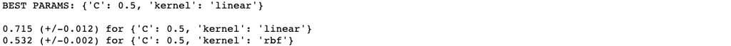

```python
# Display the best estimator with the recommended hyperplane parameters
#svm_cv.best_estimator_
```

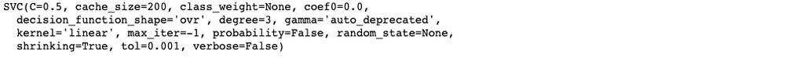

```python
# Output this to a model.pkl file
#joblib.dump(svm_cv.best_estimator_, 'SVM_reduced_model.pkl')
```

```python
# Read in Models:
reduced_models = {}

for mdl in ['LR', 'SVM']:
    reduced_models[mdl] = joblib.load('{}_reduced_model.pkl'.format(mdl))
```

```python
reduced_models
```

```
{'LR': LogisticRegression(C=0.1, class_weight=None, dual=False, fit_intercept=True,
           intercept_scaling=1, max_iter=100, multi_class='warn',
           n_jobs=None, penalty='l2', random_state=None, solver='warn',
           tol=0.0001, verbose=0, warm_start=False),
 'SVM': SVC(C=0.5, cache_size=200, class_weight=None, coef0=0.0,
   decision_function_shape='ovr', degree=3, gamma='auto_deprecated',
   kernel='linear', max_iter=-1, probability=False, random_state=None,
   shrinking=True, tol=0.001, verbose=False)}
```

```python
# Evaluate models on the test set
def evaluate_model(name, model, features, labels):
    start = time()
    pred = model.predict(features)
    end = time()
    accuracy = round(accuracy_score(labels, pred), 3)
    precision = round(precision_score(labels, pred), 3)
    recall = round(recall_score(labels, pred), 3)
    print('{} -- Accuracy: {} / Precision: {} / Recall: {} / Latency: {}ms'.format(name,
                                                                                   accuracy,
                                                                                   precision,
                                                                                   recall,
                                                                                   round((end - start)*1000, 1)))
```

```python
import joblib
import pandas as pd
from sklearn.metrics import accuracy_score, precision_score, recall_score
from time import time

for name, mdl in reduced_models.items():
    evaluate_model(name, mdl, X_test, y_test)
```

```
LR -- Accuracy: 0.711 / Precision: 0.694 / Recall: 0.731 / Latency: 2.0ms
SVM -- Accuracy: 0.709 / Precision: 0.688 / Recall: 0.74 / Latency: 3763.1ms
```

In the reduced model with features from PCA, Logistic Regression performed better with an accuracy of 71.1% and precision of 69.4%. However SVM performed better in recall with 74%. Also latency for SVM is very high and is very slow to train.

#### Performance Assessment of Models

Full Model - Logistic Regression

- Accuracy: 0.7489367540128962
- Precision: 0.7644728823887873
- Recall: 0.7035894559730791

Full Model - LR with SGD

- Accuracy: 0.7379613115653725

Full Model - SVM

- Accuracy: 0.7188914803128001
- Precision: 0.7255963705546612
- Recall: 0.6904330873137446

Reduced Models:

- LR -- Accuracy: 0.711 / Precision: 0.694 / Recall: 0.731 / Latency: 2.0ms
- LR with SGD -- Accuracy: 0.721566744409384
- SVM -- Accuracy: 0.709 / Precision: 0.688 / Recall: 0.74 / Latency: 3763.1ms

In the full model, Logistic Regression performed better than SVM in all areas with an accuracy of 74.89%, recall of 70.36% and precision of 76.44%. In addition latency for SVM is very high and is very slow to train.

In the reduced model with features from PCA, Logistic Regression performed better with an accuracy of 71.1% and precision of 69.4%. Furthermore, LR with SGD on a reduced dataset had a higher accuracy of 72.2%. However, SVM performed better in recall with 74%. Also latency for SVM is very high and is very slow to train.

# Model Advantages

**Rubric 2:** Discuss the advantages of each model for each classification task. Does one type of model offer superior performance over another in terms of prediction accuracy? In terms of training time or efficiency? Explain in detail.

As seen in detail above, in the full model, Logistic Regression performed better than SVM in all areas with an accuracy of 74.89%, recall of 70.36% and precision of 76.44%. In addition latency for SVM is very high and is very slow to train.

In the reduced model with features from PCA, Logistic Regression performed better with an accuracy of 71.1% and precision of 69.4%. Furthermore, LR with SGD on a reduced dataset had a higher accuracy of 72.2%. However, SVM performed better in recall with 74%. Also latency for SVM is very high and is very slow to train.

These indicate that Logistic Regression has most advantages over SVM for classifying high and low unemployment rates in our dataset. LR offers far superior efficiency, as it was very quick to run and even adjust parameters. SVM took too long when trying to adjust parameters, and it still took upwards of 3 hours when creating only two models to compare. In terms of prediction accuracy, Logistic Regression also had gains over the SVM models. SVM did slightly beat out LR in the recall metric for the reduced dataset, so if we were most concerned about the true positive identification rate we might opt for that model. However, the gain there is so small there that the Logistic model still seems advantageous. All this is in line with the commentary below.

Logistic Regression:

When to use LR:

- Binary target variable
- Transparency is important or interested in significance of predictors
- Fairly well-behaved data
- Need a quick initial benchmark

Logistic Regression can be considered any time we have a binary target variable and if we are interested in feature importance or to have a better understanding of what's going on within the algorithm. It should be considered when there are not too many outliers, not too many missing values, and relationships that aren't too complex. It is great for as an initial benchmark model on a binary classification problem with fairly well-behaved data. It's relatively flexible, and it's very fast to train. While it doesn't usually generate the greatest performance, it does set a very nice benchmark to start.

When not to use LR:

- Continuous target variable
- Massive data (rows or columns)
- Unwieldy data
- Performance is the only thing that matters

Logistic Regression should not be considered when we have a continuous target variable. Logistic regression also shouldn't be the first choice if we have a massive amount of data. There are other algorithms that really shine when we have a ton of data. Logistic regression is a great tool for a fast, transparent baseline model for a binary classification problem. It doesn't do well with a lot of data or particularly messy data. It's also unlikely to give the best possible performance on any given problem.

Support Vector Machines:

When to use SVM:

- Binary target variable
- Feature to row ratio is very high
- Very complex relationships
- Lots of outliers

SVM can be used for both categorical and continuous outputs. One area where SVM really excels is when the feature-to-row ratio is very high. It's when you have a lot of features and relatively few rows. SVM is also quite good at untangling complex relationships. SVM also handles data with a lot of outliers quite well, because it only looks at the points closest to the line, so that outliers are kind of ignored.

When not to use SVM:

- Feature to row ratio is very low
- Transparency is important or interested in significance of predictors
- Looking for a quick benchmark model

SVM should not be used if there are lot of rows and relatively few features. Typically, SVM will take a long time to train, and the performance really won't be worth it relative to other algorithms. SVM should be used when there are lot of features, but few rows, or when we have a lot of outliers, that we are trying to untangle. But it is quite slow to train.

# Interpret Feature Importance

**Rubric 3:** Use the weights from logistic regression to interpret the importance of different features for the classification task. Explain your interpretation in detail. Why do you think some variables are more important?

Below we display the weights from our logistic regression model, as well as a graph visualizing their relative magnitudes. When creating the model, the attributes were normalized to have the same dynamic range, so these weights are actually comparable and the weights have magnitudes that reflect their predictive power in the logistic regression model.

```python
# sort attributes by weight and spit them out
zip_vars = zip(lr_clf.coef_.T,df_17_model.columns) # combine attributes
zip_vars = sorted(zip_vars)
for coef, name in zip_vars:
    print(name, 'has weight of', coef[0]) # now print them out
```

```
White has weight of -1.6478659078362985
Hispanic has weight of -0.8812127901152838
Black has weight of -0.7107713206392208
Employed has weight of -0.6536619381522761
Asian has weight of -0.391065298271888
Income has weight of -0.16315013281763455
Native has weight of -0.14075327661750012
Professional has weight of -0.12193520306143801
Pacific has weight of -0.10178432027672049
WorkAtHome has weight of -0.07094136995677683
ChildPoverty has weight of -0.06930811045459703
TotalPop has weight of -0.04660423236942159
Construction has weight of -0.0451798085492738
FamilyWork has weight of -0.037854490615148825
Walk has weight of -0.027539372704757467
SelfEmployed has weight of -0.026602166040988005
Drive has weight of 0.017645887509381952
Office has weight of 0.03447206992067053
PrivateWork has weight of 0.04469753465777013
OtherTransp has weight of 0.04532749608851107
Carpool has weight of 0.04772308563416463
Production has weight of 0.04946658464928804
Women has weight of 0.07983736642214793
Service has weight of 0.18339282997394568
MeanCommute has weight of 0.28128475809046577
VotingAgeCitizen has weight of 0.2861622349179752
Poverty has weight of 0.587453849706721
```

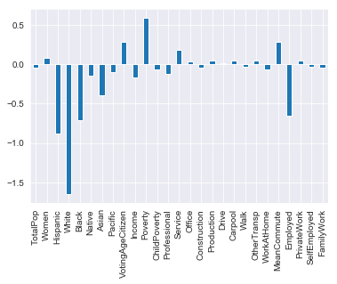

```python
weights = pd.Series(lr_clf.coef_[0],index=df_17_model.columns)
weights.plot(kind='bar')
plt.show()
```

For a binary outcome variable modeled by a logistic model, the predictor variables are assumed to have a linear relationship with the logit transformation of the response. This means that we can mathematically describe the influence of each variable on the likelihood of the response with odds ratios.

As an example, we see that the Poverty variable has a relatively large weight of 0.587. This means that the odds ratio for an increase in poverty by one unit (after being scaled) is $e^{0.587} = 1.8$. So when all other variables are held constant, the odds of a census tract having high unemployment is 1.8 times higher for the tract with the higher poverty rate than the tract with a poverty rate just one unit lower.

From just this example, we see that having a high weight in the logistic model corresponds to a high positive impact on the likelihood of a tract having high unemployment, while a high negative weight in the model reflects a large decrease in the likelihood of high unemployment (because $e$ to a negative power is a fraction, and the fractions get smaller with higher magnitudes).

Since all the variables have been scaled, interpreting all the variables individually like we did with Poverty is not incredibly meaningful, but we can certainly make comparisons between the variables based on their relative magnitudes and conclude the importance of the features. In this logistic regression model, we see that the variables having the largest weights are **White, Hispanic, Black, Employed, and Poverty**, meaning that these feature were the most important for classifying high unemployment.

In addition, it makes sense that the Employed variable had a relatively large, negative relationship with the response, because the response is measuring unemployment rates. While the percentage employed is not the direct inverse of the unemployment rate in a tract, they are certainly related. Finally, Poverty is impactful as well, but the weight in the model is positive. So as poverty percentages increase, the likelihood of high unemployment increases in the model as well. This makes sense because many people that are unemployed are likely in poverty, which makes the two variables very related. The data indicates that the rest of the variables have some influence on the model but not nearly as much as these five. Therefore we infer that these five are the most important features to observe when classifying high and low unemployment rates.

# Interpret Support Vectors

**Rubric 4:** Look at the chosen support vectors for the classification task. Do these provide any insight into the data? Explain. If you used stochastic gradient descent (and therefore did not explicitly solve for support vectors), try subsampling your data to train the SVC model— then analyze the support vectors from the subsampled dataset.

```python
svm_reduced_model = joblib.load('SVM_reduced_model.pkl'.format(mdl))
```

```python
# look at the support vectors
print(svm_reduced_model.support_vectors_.shape)
print(svm_reduced_model.support_.shape)
print(svm_reduced_model.n_support_ )
```

```
(39410, 6)
(39410,)
[19705 19705]
```

```
[[-0.0199995   0.03094172 -0.00562726  0.05093269 -0.01379212 -0.02925393]]
```

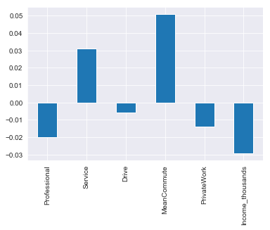

```python
print(svm_reduced_model.coef_)
weights = pd.Series(svm_reduced_model.coef_[0],index=features.columns)
weights.plot(kind='bar')
```

A support vector machine can linearly separate the data that at first glance doesn’t appear to be easily linearly separable. By adding higher dimensions to the data, a dimension were the data can be linearly separable can be found. The vector above below is the vector that is orthogonal to the plane the machine has selected to linearly separate the unemployment classes. So, if you were to take the dot product of the explanatory variables of a tract and the output vector, the result would tell you what class the tract would belong to. A positive dot product would result in the row belonging to one class and a negative dot product would indicate the other class.

The vector chosen to separate the classes into high unemployment and low unemployment uses the percent of people with professional jobs, the percent of people with service jobs, the percent of people that drive to work, mean commute time, the percent of people in the private sector, and income in thousands. Mean commute time has the biggest absolute weight followed by population percent in service jobs and then income in thousands. This indicates that these variables are important in determining the separation plane.

Income in thousands being important makes sense because if the median income is high in a tract it is less likely that large numbers of people will be unemployed in that tract. However, mean commute time and service jobs are interesting variables to have an influence on discerning whether or not the tract has high unemployment of low unemployment. It will be interesting to further analyze the relationship between these variables and unemployment rates.

### References:

- **[Applied Machine Learning: Algorithms | LinkedIn Learning](https://www.linkedin.com/learning/applied-machine-learning-algorithms/)**
- **[Feature-importance](https://stats.stackexchange.com/questions/336404/feature-importance-for-breast-cancer-random-forests-vs-logistic-regression)**
- **[Model based importance](https://towardsdatascience.com/model-based-feature-importance-d4f6fb2ad403)**
- **[skikit-learn](https://scikit-learn.org/stable/modules/sgd.html)**